# Psych 251 Comprehension Pilot A: Gick (1983)

Greses Perez

November 25th, 2018

This is pilot A is a pilot of my study with non-naive participants. In this document, you will find:

1. The “data” collected from me and my friends to guarantee that the data is logging correctly.
2. The feedback on the paradigm that I got by running it several times.
3. The code for my planned analyses
4. The confirmation that I can run the code on my data.
5. The rendered replication report.
6. The link to my paradigm.
7. The limited data that I collected analyzed via the confirmatory analyses.
8. The different conditions included in the paradigm.

```r
# load packages
library(tidyverse) # for data munging
library(knitr) # for kable table formating
library(haven) # import and export 'SPSS', 'Stata' and 'SAS' Files
library(readxl) # import excel files
library(CARPSreports) # custom report functions

library('dplyr')      # for data manipulation
library('tidyr')      # for reshaping data
library(plyr)
```

```r
library('ggplot2')    # plotting data
library('scales')     # for scale_y_continuous(label = percent)
library('ggthemes')   # for scale_fill_few('medium')
knitr::opts_chunk$set(comment = NA)
options(ztable.type = 'html')
#install.packages("ez") #Uncomment and run this line if you do not have "ez" installed
library(ez)
library(lsr) #for ANOVA effect size calculations
```

1. First, let’s look at the “data” collected from me and my friends to guarantee that the data is logging correctly. This was my first attempt to raw data that I collected with three samples in total. The data was logging in correctly, but I have more information than needed it for this experiment.

```r
library(readr)
rawdata <- read_csv("~/Desktop/PhD Stanford /PSYCH-251 Experimental Methods/Final Project /PilotA/Trial 2_PilotA/Data_Trial2_PilotA.csv")
head(rawdata)
```

```
# A tibble: 4 x 24
  StartDate EndDate Progress `Duration (in s… RecordedDate ResponseId Q1
  <chr>     <chr>   <chr>    <chr>            <chr>        <chr>      <chr>
1 Start Da… End Da… Progress Duration (in se… Recorded Da… Response … Gend…
2 11/25/18… 11/25/… 100      137              11/25/18 17… R_u8KIu3Y… Pref…
3 11/25/18… 11/25/… 100      35               11/25/18 17… R_2AMWJ5p… Pref…
4 11/25/18… 11/25/… 100      387              11/25/18 17… R_2Xb76xN… Fema…
# ... with 17 more variables: Q1_3_TEXT <chr>, Q2 <chr>, Q3 <chr>,
#   Q24 <chr>, Q22 <chr>, Q26 <chr>, Q27 <chr>, Q28 <chr>, Q29_1 <chr>,
#   Q54 <chr>, Q55 <chr>, Q58 <chr>, Q59 <chr>, Q60 <chr>, Q61_1 <chr>,
#   Q47 <chr>, Q41 <chr>
```

2. The feedback on the paradigm that I got by running it several times. After running the paradigm several times, the users advised me to put a break page between the stories and allow for users to click on continue when they have finished with their stories. Please see below the clean data based on the raw data presented on the previous section.

```r
d <- read_csv("~/Desktop/PhD Stanford /PSYCH-251 Experimental Methods/Final Project /PilotA/Trial 2_PilotA/Table A_Data_Trial2_PilotA.csv")
head(d)
```

```
# A tibble: 3 x 5
  Subject Condition BeforeHint AfterHint Comprenhensibility
    <int>     <int>      <int>     <int> <chr>
1     111         1          0         1 Good
2     112         1          1         1 Poor
3     113         2          1         1 Intermediate
```

3. The code for my planned analyses and 4. The confirmation that I can run the code on my data.

```r
#Total With Principle condition
Total_WP = sum(with(d, Condition==1))
Total_WP
```

```
[1] 2
```

```r
#Total Without Principle
Total_WOP = sum(with(d, Condition==2))
Total_WOP
```

```
[1] 1
```

```r
# Frequency of convergence solution with principle before hint
ds <- d %>%
  filter(Condition==1 & BeforeHint==1)
y = count(ds, 'BeforeHint')
#Percentage of convergence solution with principle before hint
mutate (y, PY=((y$freq/Total_WP)*100))
```

```
  BeforeHint freq PY
1          1    1 50
```

```r
# Frequency of convergence solution with principle after hint
dt <- d %>%
  filter(Condition==1 & AfterHint==1)
x = count(dt, 'AfterHint')-y
#Percentage of convergence solution with principle before hint
mutate (x, PX=((x$freq/Total_WP)*100))
```

```
  AfterHint freq PX
1         0    1 50
```

```r
# Frequency of convergence solution without principle before hint
dv <- d %>%
  filter(Condition==2 & BeforeHint==1)
z = count(dv, 'BeforeHint')
#Percentage of convergence solution Without principle before hint
mutate (z, PZ=((z$freq/Total_WOP)*100))
```

```
  BeforeHint freq  PZ
1          1    1 100
```

```r
# Frequency of convergence solution without principle after hint
dw <- d %>%
  filter(Condition==2 & AfterHint==1)
a = count(dw, 'AfterHint')-z
#Percentage of convergence solution Without principle before hint
mutate (a, PA=((a$freq/Total_WOP)*100))
```

```
  AfterHint freq PA
1         0    0  0
```

5.a The repository folder

> [Replication report could be found in GitHub folder “PilotA_V2”](https://github.com/greses/gick1983.git)

5.b The rendered replication report.

> [Rendered replication report](http://rpubs.com/Greses88/442889)
6. The link to my paradigm.

> [Link to paradigm or survey data collection instrument](https://stanforduniversity.qualtrics.com/jfe/form/SV_ezc7nSOpcZjrgC9)
7. The limited data that I collected analyzed via the confirmatory analyses.

```r
TAB <-matrix(c(1,1,1,0),ncol = 2, byrow = TRUE)
colnames(TAB) <- c("Before_Hint","After_Hint")
rownames(TAB) <- c("With_Principle", "Without_Principle")
TAB <- as.table(TAB)
TAB
```

```
                  Before_Hint After_Hint
With_Principle              1          1
Without_Principle           1          0
```

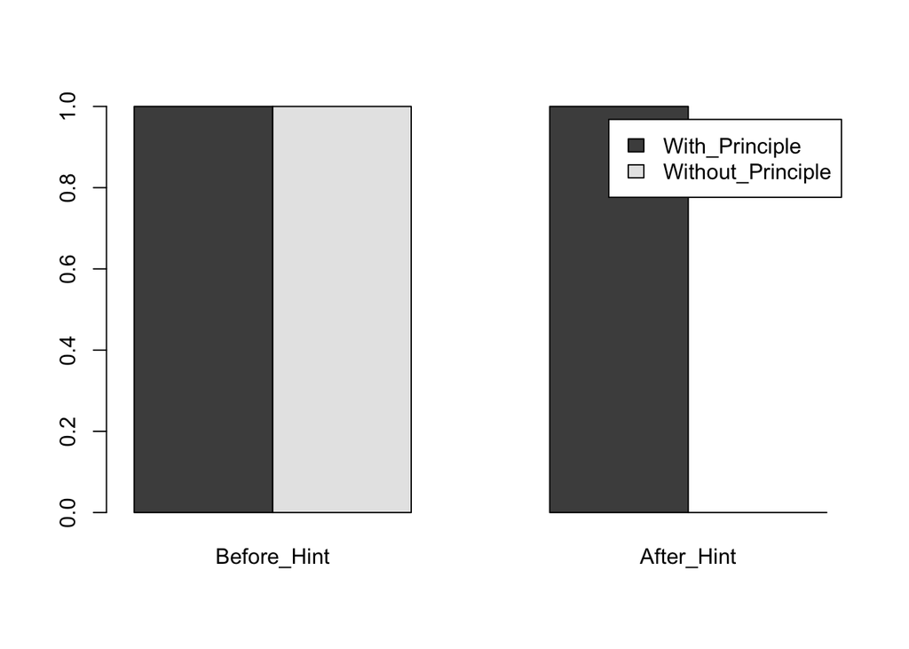

```r
barplot(TAB, beside = TRUE, legend=TRUE)
```

```r
CHI = chisq.test(TAB, correct = T)
CHI
```

```
    Pearson's Chi-squared test with Yates' continuity correction

data:  TAB
X-squared = 4.6222e-32, df = 1, p-value = 1
```

```r
attributes(CHI)
```

```
$names
[1] "statistic" "parameter" "p.value"   "method"    "data.name" "observed"
[7] "expected"  "residuals" "stdres"

$class
[1] "htest"
```

8. The different conditions included in the paradigm. > There are two conditions included in the paradigm: with principle and without principle condition. A principle is a statement at the end of the stories that makes explicit the solution to the problem. In both conditions, participants are asked to solve the “Radiation Problem”, first without a hint and later with a hint.